# 15 C power analysis-aphids-autocorrelation-1_4_cat

nbutool

01/03/2022

The purpose of this document is to display the results of the Power analysis for each mean temperature (15, 19, 23, 27) for the aphid data. For each temperature there will be 4 results total as follows.

1. Anova summary comparing 0 to 0.95 m<0, categorization based on whole sequence
2. Anova summary comparing 0 to 0.95 m>0, categorization based on whole sequence
3. Anova summary comparing 0 to 0.95 m<0, categorization based on first 1/4th of sequence
4. Anova summary comparing 0 to 0.95 m>0, categorization based on first 1/4th of sequence

In this document we’ll focus on cat_1_4.

##No. of acceptable samples per temperature

```r
#Power analysis for autocorrelation experiments - duckweed
#based on file named simpleanovathermal.Rmd

#Download the data from github repo and check import
datin <- read.csv("https://raw.githubusercontent.com/Cuddington-Lab/thermal-experiments/main/expdata_metafile_FEB_20_22.csv",
                  header=TRUE, stringsAsFactors = TRUE)
str(datin)
```

```
## 'data.frame':    130 obs. of  23 variables:
##  $ Experiment_Number: int  2 2 2 2 3 3 3 3 4 4 ...
##  $ Mean_Temp        : int  15 15 15 15 19 19 19 19 23 23 ...
##  $ Experiment_Start : Factor w/ 38 levels "02-Aug-20","03-Dec-21",..: 32 32 32 32 1 1 1 1 12 12 ...
##  $ Experiment_End   : Factor w/ 38 levels "02-Feb-22","02-Oct-20",..: 38 38 38 38 7 7 7 7 18 18 ...
##  $ Profile_name     : Factor w/ 113 levels "Simplelong 15_095_06",..: 21 34 27 35 45 47 48 50 52 53 ...
##  $ Autocorrelation  : num  0 0.9 0.6 0.9 0 0.6 0.95 0.95 0 0.6 ...
##  $ Incubator        : int  1 3 5 6 1 3 5 6 1 3 ...
##  $ Offspring_Plant1 : int  0 6 0 0 12 19 22 19 21 23 ...
##  $ Offspring_Plant2 : int  8 6 3 0 16 16 23 17 21 26 ...
##  $ Offspring_Plant3 : int  1 0 4 1 21 14 8 8 22 20 ...
##  $ Duckweed_Rep1    : int  NA NA NA NA NA NA NA NA NA NA ...
##  $ Duckweed_Rep2    : int  NA NA NA NA NA NA NA NA NA NA ...
##  $ Duckweed_Rep3    : int  NA NA NA NA NA NA NA NA NA NA ...
##  $ cat_1            : Factor w/ 4 levels "","N","N/A","P": 3 1 3 1 3 3 2 4 3 3 ...
##  $ cat_1_4          : Factor w/ 4 levels "","N","N/A","P": 3 1 3 1 3 3 4 2 3 3 ...
##  $ Program_mean     : num  NA NA NA NA NA ...
##  $ Obs_mean         : num  NA NA NA NA NA ...
##  $ Program_sd       : num  NA NA NA NA NA ...
##  $ Obs_sd           : num  NA NA NA NA NA ...
##  $ Program_ac       : num  NA NA NA NA NA ...
##  $ Obs_ac           : num  NA NA NA NA NA ...
##  $ Gaps             : Factor w/ 3 levels "","n","y": 2 2 2 2 1 2 2 2 2 2 ...
##  $ Gap_size         : Factor w/ 8 levels "","35h","36h",..: 1 1 1 1 1 1 1 1 1 1 ...
```

```r
#Exclude NAs and samples with standard deviations too different from set value of 2.5
#(code for duckweeds, needs to be adapted for aphids)
datin <- subset(datin, Offspring_Plant1 != "NA" & Obs_sd < 2.7 & Obs_sd > 2.2 & Gaps != "y")

#Create new treatment label and check
table(datin$Autocorrelation, datin$cat_1_4)
```

```
##
##            N N/A  P
##   0     0  0  22  0
##   0.95  0 21   0 25
```

```r
levels(datin$cat_1_4) = c("","m<0","", "m>0" )
datin$label<-paste0(datin$Autocorrelation, datin$cat_1_4)
table(datin$label)
```

```
##
##       0 0.95m<0 0.95m>0
##      22      21      25
```

```r
#Create new column including sum of fronds (sumFro)
datin$sumFro=datin$Offspring_Plant1+datin$Offspring_Plant2+datin$Offspring_Plant3
datin <- subset(datin, sumFro != "NA")
table(datin$Mean_Temp, datin$label)
```

```
##
##       0 0.95m<0 0.95m>0
##   15  6       5       6
##   19  0       1       1
##   23  3       6       4
##   27 13       9      14
```

# 15 deg C

```r
#Select mean temp of 15C
dat27 <- subset(datin, Mean_Temp == 15)

#Perform power analysis based on preliminary data
#Source: https://med.und.edu/daccota/_files/pdfs/berdc_resource_pdfs/sample_size_r_module.pdf
library(pwr)
```

## Categorization for 1/4th of whole sequence

checking 0 to 0.95m<0

```r
#Subset data to include only one 0.95 autocorrelation group and control group
#Obtain same number of samples for each group
datpower <- rbind(dat27[ sample(which (dat27$label == "0") ,5), ],
                  dat27[ sample(which (dat27$label == "0.95m<0") ,5), ])
```

Producing boxplot

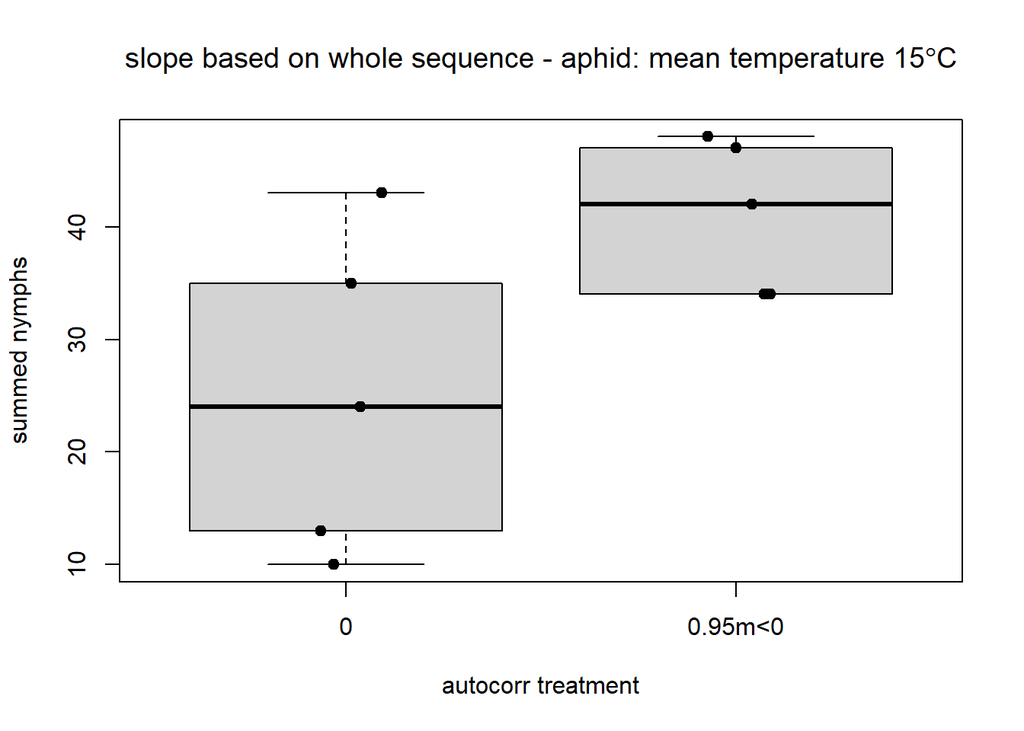

```r
#BoxPlot
tr=boxplot(sumFro~label, data=datpower,main=expression(paste("slope based on whole sequence - aphid: mean temperature 15",degree,"C")),outline=FALSE,
           xlab="autocorr treatment", ylab="summed nymphs",
           names = levels(as.factor(datpower$label)))
stripchart(sumFro~label, data=datpower,
           vertical = TRUE, method = "jitter",
           pch = 19, add = TRUE)
```

power analysis results

```r
#Perform anova
anova <- aov(sumFro~label, data=datpower)
summary(anova)
```

```
##             Df Sum Sq Mean Sq F value Pr(>F)
## label        1    640   640.0   5.235 0.0514 .
## Residuals    8    978   122.2
## ---
## Signif. codes:  0 '***' 0.001 '**' 0.01 '*' 0.05 '.' 0.1 ' ' 1
```

```r
#Obtain effect size
library(effectsize)
#https://cran.r-project.org/web/packages/effectsize/vignettes/anovaES.html
effectsize <- eta_squared(anova, partial = FALSE)
summary(effectsize)
```

```
##   Parameter              Eta2              CI           CI_low     CI_high
##  Length:1           Min.   :0.3956   Min.   :0.95   Min.   :0   Min.   :1
##  Class :character   1st Qu.:0.3956   1st Qu.:0.95   1st Qu.:0   1st Qu.:1
##  Mode  :character   Median :0.3956   Median :0.95   Median :0   Median :1
##                     Mean   :0.3956   Mean   :0.95   Mean   :0   Mean   :1
##                     3rd Qu.:0.3956   3rd Qu.:0.95   3rd Qu.:0   3rd Qu.:1
##                     Max.   :0.3956   Max.   :0.95   Max.   :0   Max.   :1
```

```r
#Perform power test to obtain estimated "n" in each group based on effect size
pwr.anova.test(k = 2, f = effectsize$Eta2, sig.level = 0.05, power = 0.80)
```

```
##
##      Balanced one-way analysis of variance power calculation
##
##               k = 2
##               n = 26.07873
##               f = 0.3955501
##       sig.level = 0.05
##           power = 0.8
##
## NOTE: n is number in each group
```

checking 0 to 0.95m>0

producing boxplot

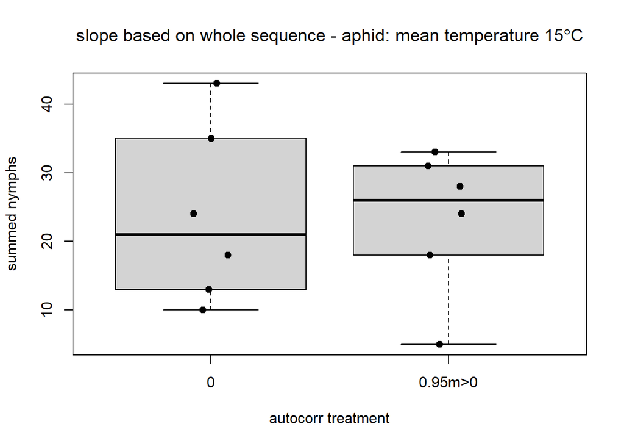

power analysis results

```
##             Df Sum Sq Mean Sq F value Pr(>F)
## label        1    1.3    1.33    0.01  0.923
## Residuals   10 1373.7  137.37
```

```
##   Parameter              Eta2                 CI           CI_low     CI_high
##  Length:1           Min.   :0.0009697   Min.   :0.95   Min.   :0   Min.   :1
##  Class :character   1st Qu.:0.0009697   1st Qu.:0.95   1st Qu.:0   1st Qu.:1
##  Mode  :character   Median :0.0009697   Median :0.95   Median :0   Median :1
##                     Mean   :0.0009697   Mean   :0.95   Mean   :0   Mean   :1
##                     3rd Qu.:0.0009697   3rd Qu.:0.95   3rd Qu.:0   3rd Qu.:1
##                     Max.   :0.0009697   Max.   :0.95   Max.   :0   Max.   :1
```

```
##
##      Balanced one-way analysis of variance power calculation
##
##               k = 2
##               n = 4173540
##               f = 0.000969697
##       sig.level = 0.05
##           power = 0.8
##
## NOTE: n is number in each group
```

Note the code is not shown for the second iteration comparing 0 to 0.95 m>0 since it’s the same as the other code, just the sample size is changed.